# Applied regression modeling in R

Authors

Guy-Alain Schnidrig (VPHI)

Filipe Miguel Maximiano Alves de Sousa (VPHI)

Eleftheria Michalopoulou (ISPM)

Beatriz Vidondo (VPHI)

Ben Spycher (ISPM)

### Information

Exercises (solution R-code provided) for [Linear and Logistic Regression Modelling in R](https://zuw.me/kurse/dt.php?kid=4476) course of the [Public Health Sciences Course Program](https://www.medizin.unibe.ch/studies/study_programs/phs_course_program) at the [University of Bern](https://www.unibe.ch/).

To follow along with the course, we recommend that you open a new R-Script (or Quarto/Markdown). Create a new folder on your local machine and copy the data sets from ILIAS to it.

Before starting the exercises, you should run the provided setup chunk at least once.

Side note: The pipe operator is written as `%>%` or `|>`, and it takes the result of the expression on its left and passes it as the first argument to the function on its right. In other words, it allows you to apply a series of functions to a data object step by step.

```r
10 %>%
  + 5 %>%
  - 2
```

```
[1] 13
```

# Simple linear regression

## Load data

Load `perulung` data using the function `read_csv()`.

```r
# Load the csv file
perulung <- read_csv("../data/perulung_ems.csv", show_col_types = FALSE)
```

#### Exercise 1

Use `head()` to display the first 10 rows of the data.

```r
perulung %>%
  head(10) %>%
  kable()
```

| id | fev1 | age | height | sex | respsymptoms | asthma_hist |
| --- | --- | --- | --- | --- | --- | --- |
| 638 | 0.64 | 7.469 | 118.4 | 1 | 1 | current asthma |
| 527 | 0.68 | 8.213 | 112.9 | 0 | 1 | never |
| 33 | 0.81 | 8.419 | 120.8 | 0 | 0 | never |
| 289 | 0.81 | 7.457 | 109.2 | 0 | 0 | never |
| 254 | 0.82 | 8.953 | 128.0 | 0 | 1 | current asthma |
| 355 | 0.83 | 8.485 | 115.0 | 0 | 1 | previous asthma |
| 484 | 0.85 | 8.471 | 131.5 | 1 | 1 | previous asthma |
| 86 | 0.86 | 7.562 | 113.0 | 0 | 0 | never |
| 601 | 0.86 | 8.581 | 126.7 | 1 | 0 | never |
| 242 | 0.89 | 9.052 | 109.4 | 1 | 1 | never |

## Data wrangling

#### Exercise 2

Apply the transformations from slide 29 in `Simple Regression.html`.

```r
perulung <- perulung  %>%
  mutate(id = as.integer(id),
         sex = factor(sex, levels = c(0,1), labels=c("f","m")),
         respsymptoms = factor(respsymptoms, levels=c(0,1), labels=c("no","yes")),
         asthma_hist = factor(asthma_hist, levels=c("never", "previous asthma", "current asthma"),
                              labels=c("never", "previous asthma", "current asthma")))
```

## Data visualizations and model assumptions

It is always recommended to visualize your data before you run any kind of analysis.

#### Exercise 3

Plot the `fev1` and `height` as histograms and inspect their distributions.

Use `ggplot()` and `geom_histogram()`.

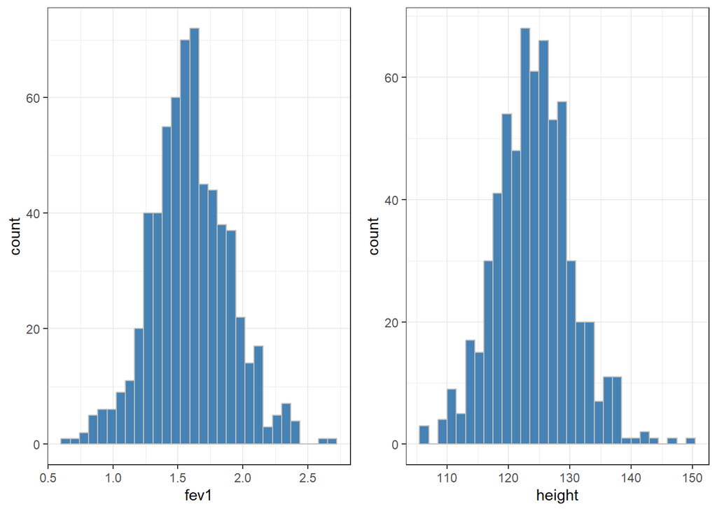

```r
plot_height <- perulung %>%
  ggplot(aes(x = fev1)) +
  geom_histogram(bins = 30,
                 fill = "steelblue",
                 color = "grey") +
  theme_bw()


plot_fev1 <- perulung %>%
  ggplot(aes(x = height)) +
  geom_histogram(bins = 30,
                 fill = "steelblue",
                 color = "grey") +
  theme_bw()


grid.arrange(plot_height, plot_fev1, ncol = 2)
```

#### Exercise 3

Plot lung function `fev1` and `height` in a scatter plot.  
Describe the plot in your own words.  
Use `ggplot()` and `geom_point`.

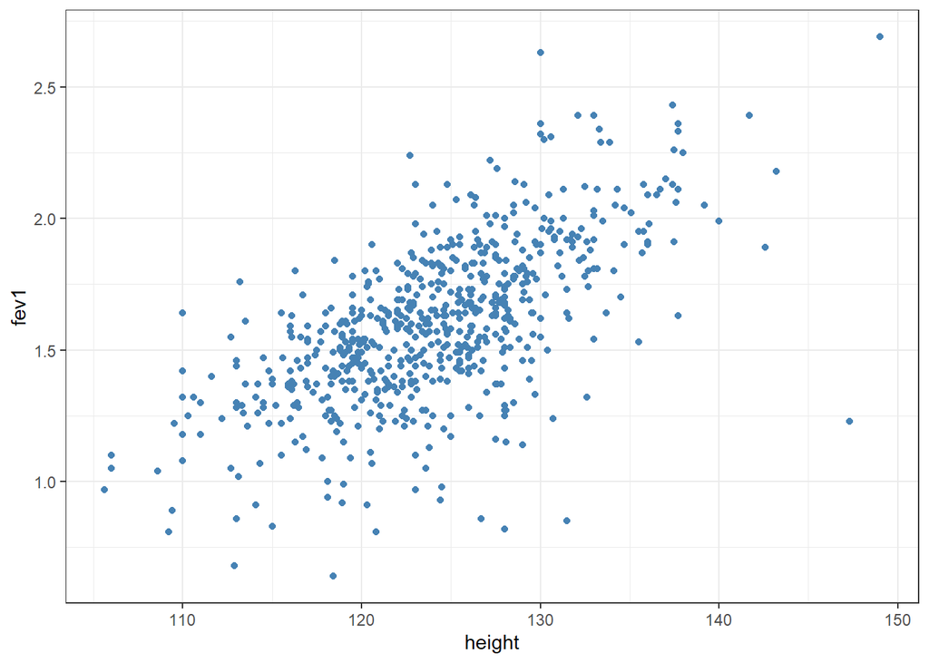

```r
perulung %>%
  ggplot(aes(x = height, y = fev1)) +
  geom_point(color = "steelblue") +
  theme_bw()
```

#### Exercise 4

As we can see the points seem to be correlated.  
To confirm that, calculate the pearson correlation of `fev1` and `height` with `cor()`.

```r
cor(perulung$fev1, perulung$height, method = c("pearson"))
```

```
[1] 0.6376096
```

## Least squares estimation (LSE)

#### Exercise 5

Calculate the regression coefficients $\hat{b1}$ and $\hat{b0}$ according to slide 13 and given that:

```r
x = perulung$height
y = perulung$fev1
```

Use `cor()`, `sd()` and `mean()`.

```r
b1 = (cor(y, x) * sd(y)) / sd(x)
b0 = mean(y) - b1 * mean(x)


cat("b1:", b1,"b0:", b0)
```

```
b1: 0.03111954 b0: -2.265817
```

#### Exercise 6

Use the function `lm()` to preform a simple linear regression. This will apply the method of least squares to fit regression line.  
Use `summary()` to inspect your results.

1. Are your calculated $\hat{b1}$ and $\hat{b0}$ the same as the ones from `lm()`?

```r
model_1 <- lm(fev1 ~ height, data = perulung)
summary(model_1)
```

```
Call:
lm(formula = fev1 ~ height, data = perulung)

Residuals:
    Min      1Q  Median      3Q     Max
-1.0881 -0.1329  0.0173  0.1452  0.8503

Coefficients:
             Estimate Std. Error t value Pr(>|t|)
(Intercept) -2.265817   0.185474  -12.22   <2e-16 ***
height       0.031120   0.001493   20.84   <2e-16 ***
---
Signif. codes:  0 '***' 0.001 '**' 0.01 '*' 0.05 '.' 0.1 ' ' 1

Residual standard error: 0.2347 on 634 degrees of freedom
Multiple R-squared:  0.4065,    Adjusted R-squared:  0.4056
F-statistic: 434.3 on 1 and 634 DF,  p-value: < 2.2e-16
```

#### Exercise 7

Given your fitted regression, what is the predicted `fev1` of a child that is `113.8 cm` tall?  
Try to calculate it with $\hat{b0}$ + $\hat{b1}$ or use `predict()`.  
What happens if you predict with a value that was not originally in the range of the data frame?

```r
# Y = b0 + b1*X
Y = b0 + b1 * 113.8

# Predict
Y_predict = predict(model_1, newdata = data.frame(height = 113.8))

cat("Y:",Y ,"Y_predict:", Y_predict)
```

```
Y: 1.275586 Y_predict: 1.275586
```

#### Exercise 8

One easier way to deal with the output of `summary()` on our model is to store it with `tidy()`.  
Use `tidy()` to tidy up your model coefficients and store them in a tibble.  
Try to include the confidence interval.

```r
summary_model_1 <- model_1 %>%
  tidy(conf.int = TRUE)

summary_model_1 %>%
  kable()
```

| term | estimate | std.error | statistic | p.value | conf.low | conf.high |
| --- | --- | --- | --- | --- | --- | --- |
| (Intercept) | -2.2658174 | 0.1854735 | -12.21639 | 0 | -2.6300341 | -1.9016007 |
| height | 0.0311195 | 0.0014932 | 20.84039 | 0 | 0.0281873 | 0.0340518 |

```r
t <- summary(model_1)
```

#### Exercise 9

Use `glance()` to store more components of the model summary in a tibble.  
How much variance of `fev1` is explained by `height`?

```r
components_model_1 <- model_1 %>%
  glance()

components_model_1 %>%
  kable()
```

| r.squared | adj.r.squared | sigma | statistic | p.value | df | logLik | AIC | BIC | deviance | df.residual | nobs |
| --- | --- | --- | --- | --- | --- | --- | --- | --- | --- | --- | --- |
| 0.406546 | 0.4056099 | 0.2347217 | 434.3221 | 0 | 1 | 20.34631 | -34.69262 | -21.32702 | 34.92977 | 634 | 636 |

#### Exercise 10

Implement a *t*-test by hand using `pt()` as it is described on slide 41.  
Use the `estimate` and the `std.error` saved in your model summary.  
Compare your results to the `p.value` of your fitted regression.

```r
t_test <- summary_model_1$estimate / summary_model_1$std.error

p <- 2*pt(-abs(t_test), components_model_1$df.residual)
p
```

```
[1] 5.694479e-31 7.225656e-74
```

```r
summary_model_1$p.value
```

```
[1] 5.694479e-31 7.225656e-74
```

## Regression line

#### Exercise 11

Standardize `fev1` and `height` (`(i - mean(i)) / sd(i)`) and re-run `lm()` with them. This way you can verify that the fitted slope is the same as the correlation in Exercise 4.

```r
x_norm <- (x - mean(x)) / sd(x)
y_norm <- (y - mean(y)) / sd(y)

cor(x_norm, y_norm, method = c("pearson"))
```

```
[1] 0.6376096
```

```r
lm(y_norm ~ x_norm)
```

```
Call:
lm(formula = y_norm ~ x_norm)

Coefficients:
(Intercept)       x_norm
  1.279e-15    6.376e-01
```

```r
cor(perulung$fev1, perulung$height, method = c("pearson"))
```

```
[1] 0.6376096
```

#### Exercise 12

Use `ggplot()` to recreate the scatter plot from Exercise 3 and then add a regression line using `stat_poly_line`.  
Try to add the regression equation and the adjusted R<sup>2</sup> with `stat_poly_eq().  
Evaluate how “good” your regression line is.

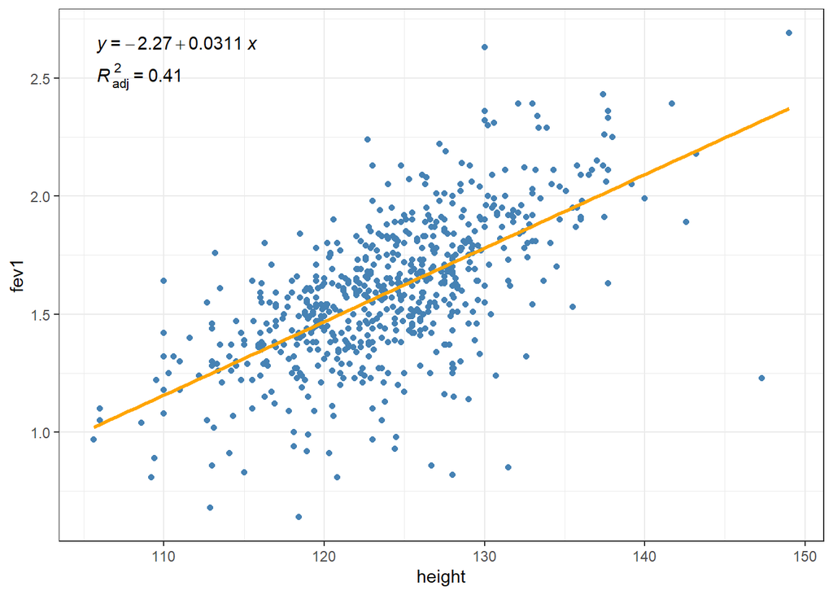

```r
perulung %>%
  ggplot(aes(x = height, y = fev1)) +
  geom_point(color = "steelblue") +
  stat_poly_line(color = "orange", se = FALSE) +
  stat_poly_eq(use_label(c("eq"))) +
  stat_poly_eq(use_label(c("adj.R2")), label.y = 0.9) +
  theme_bw()
```

# Multiple linear regression

## Including multiple independent variables

We will now examine a data set that includes the birth weight of children.  
The data was collected in 1986 at Baystate Medical Center in Springfield, Massachusetts. More information on the variables you find [here](https://stat.ethz.ch/R-manual/R-devel/library/MASS/html/birthwt.html).

```r
# Rename the columns to have more descriptive names
birthwt <- MASS::birthwt %>%
  rename(birthweight_below_2500 = low,
         mother_age = age,
         mother_weight = lwt,
         ethnicity = race,
         mother_smokes = smoke,
         previous_prem_labor = ptl,
         hypertension = ht,
         uterine_irr = ui,
         physician_visits = ftv,
         birthweight = bwt)

# Recode the factors
birthwt <- birthwt %>%
  mutate(birthweight_below_2500 = factor(birthweight_below_2500, levels = c(0,1), labels=c("no","yes")),
         ethnicity = factor(ethnicity, levels = c(1,2,3), labels=c("White","Black", "Other")),
         mother_smokes = factor(mother_smokes, levels = c(0,1), labels=c("no","yes")),
         hypertension = factor(hypertension, levels = c(0,1), labels=c("no","yes")),
         uterine_irr = factor(uterine_irr, levels = c(0,1), labels=c("no","yes")))

#standardize numerical variables (center to their means and scale to their sd's)
birthwt <- birthwt %>%
  mutate(mother_age_c = scale(mother_age,center=T,scale=T),
         mother_weight_c = scale(mother_weight,center=T,scale=T),
  )

birthwt %>%
  head(5) %>%
  kable()
```

|  | birthweight_below_2500 | mother_age | mother_weight | ethnicity | mother_smokes | previous_prem_labor | hypertension | uterine_irr | physician_visits | birthweight | mother_age_c | mother_weight_c |
| --- | --- | --- | --- | --- | --- | --- | --- | --- | --- | --- | --- | --- |
| 85 | no | 19 | 182 | Black | no | 0 | no | yes | 0 | 2523 | -0.7998401 | 1.7065482 |
| 86 | no | 33 | 155 | Other | no | 0 | no | no | 3 | 2551 | 1.8423284 | 0.8236002 |
| 87 | no | 20 | 105 | White | yes | 0 | no | no | 1 | 2557 | -0.6111138 | -0.8114885 |
| 88 | no | 21 | 108 | White | yes | 0 | no | yes | 2 | 2594 | -0.4223875 | -0.7133832 |
| 89 | no | 18 | 107 | White | yes | 0 | no | yes | 0 | 2600 | -0.9885665 | -0.7460849 |

#### Exercise 13

Create an univariate linear regression model with `birthweight` as the outcome and `mother_smokes` as the explanatory variable.

1. What is the equation of the regression line, how do you interpret the regression coefficients? why there is not an estimate for `mother_smokesno`?
2. How well does the model fit the data, and what is the value of the R-squared statistic?
3. Describe the effect of `mother_smokes` on the `birthweight`.

```r
model_uni <- lm(birthweight ~ mother_smokes, data = birthwt)
summary(model_uni)
```

```
Call:
lm(formula = birthweight ~ mother_smokes, data = birthwt)

Residuals:
    Min      1Q  Median      3Q     Max
-2062.9  -475.9    34.3   545.1  1934.3

Coefficients:
                 Estimate Std. Error t value Pr(>|t|)
(Intercept)       3055.70      66.93  45.653  < 2e-16 ***
mother_smokesyes  -283.78     106.97  -2.653  0.00867 **
---
Signif. codes:  0 '***' 0.001 '**' 0.01 '*' 0.05 '.' 0.1 ' ' 1

Residual standard error: 717.8 on 187 degrees of freedom
Multiple R-squared:  0.03627,   Adjusted R-squared:  0.03112
F-statistic: 7.038 on 1 and 187 DF,  p-value: 0.008667
```

Now build a model with `mother_weight`. Compare it to a model with standardized `mother_weight_c`

1. Interpret the intercept for `mother_weight_c`.
2. How does it compare to the overall average of birthweight (crude estimate)?

```r
model_two <- lm(birthweight ~ mother_weight, data = birthwt)
summary(model_two)
```

```
Call:
lm(formula = birthweight ~ mother_weight, data = birthwt)

Residuals:
     Min       1Q   Median       3Q      Max
-2192.12  -497.97    -3.84   508.32  2075.60

Coefficients:
              Estimate Std. Error t value Pr(>|t|)
(Intercept)   2369.624    228.493  10.371   <2e-16 ***
mother_weight    4.429      1.713   2.585   0.0105 *
---
Signif. codes:  0 '***' 0.001 '**' 0.01 '*' 0.05 '.' 0.1 ' ' 1

Residual standard error: 718.4 on 187 degrees of freedom
Multiple R-squared:  0.0345,    Adjusted R-squared:  0.02933
F-statistic: 6.681 on 1 and 187 DF,  p-value: 0.0105
```

```r
model_three <- lm(birthweight ~ mother_weight_c, data = birthwt)
summary(model_three)
```

```
Call:
lm(formula = birthweight ~ mother_weight_c, data = birthwt)

Residuals:
     Min       1Q   Median       3Q      Max
-2192.12  -497.97    -3.84   508.32  2075.60

Coefficients:
                Estimate Std. Error t value Pr(>|t|)
(Intercept)      2944.59      52.26  56.346   <2e-16 ***
mother_weight_c   135.44      52.40   2.585   0.0105 *
---
Signif. codes:  0 '***' 0.001 '**' 0.01 '*' 0.05 '.' 0.1 ' ' 1

Residual standard error: 718.4 on 187 degrees of freedom
Multiple R-squared:  0.0345,    Adjusted R-squared:  0.02933
F-statistic: 6.681 on 1 and 187 DF,  p-value: 0.0105
```

```r
mean(birthwt$birthweight)
```

```
[1] 2944.587
```

Now build a model with two variables, `mother_smokes` and `mother_weight`

1. Interpret the slope of the `mother_weight`.
2. Is R-squared different, and if so, why?
3. Reformulate your interpretation of the effect of `mother_smokes` on the `birthweight`.
4. Describe the effect of `mother_weight` on `birthweight`.

```r
model_four <- lm(birthweight ~ mother_smokes + mother_weight, data = birthwt)
summary(model_four)
```

```
Call:
lm(formula = birthweight ~ mother_smokes + mother_weight, data = birthwt)

Residuals:
     Min       1Q   Median       3Q      Max
-2030.90  -445.69    29.16   521.76  1967.76

Coefficients:
                 Estimate Std. Error t value Pr(>|t|)
(Intercept)      2501.125    230.836  10.835   <2e-16 ***
mother_smokesyes -272.081    105.591  -2.577   0.0107 *
mother_weight       4.237      1.690   2.507   0.0130 *
---
Signif. codes:  0 '***' 0.001 '**' 0.01 '*' 0.05 '.' 0.1 ' ' 1

Residual standard error: 707.8 on 186 degrees of freedom
Multiple R-squared:  0.06777,   Adjusted R-squared:  0.05775
F-statistic: 6.761 on 2 and 186 DF,  p-value: 0.001464
```

Add the variables `mother_age` and `hypertension` to your model.

1. How well does the model fit the data, and what is the value of the R-squared statistic?
2. Reformulate your description of the effect of `mother_smokes` on the `birthweight`.
3. Does a history of hypertension during pregnancy influence the birth weight of children?

```r
model_full <- lm(birthweight ~ mother_smokes + mother_age + mother_weight + hypertension, data = birthwt)
summary(model_full)
```

```
Call:
lm(formula = birthweight ~ mother_smokes + mother_age + mother_weight +
    hypertension, data = birthwt)

Residuals:
     Min       1Q   Median       3Q      Max
-2096.33  -431.98     5.35   507.85  1819.81

Coefficients:
                 Estimate Std. Error t value Pr(>|t|)
(Intercept)      2284.687    297.097   7.690 8.59e-13 ***
mother_smokesyes -262.972    104.072  -2.527  0.01235 *
mother_age          5.563      9.778   0.569  0.57009
mother_weight       5.164      1.744   2.961  0.00347 **
hypertensionyes  -579.090    214.434  -2.701  0.00757 **
---
Signif. codes:  0 '***' 0.001 '**' 0.01 '*' 0.05 '.' 0.1 ' ' 1

Residual standard error: 697 on 184 degrees of freedom
Multiple R-squared:  0.1058,    Adjusted R-squared:  0.08639
F-statistic: 5.444 on 4 and 184 DF,  p-value: 0.0003645
```

## F-test

#### Exercise 13

Execute a F-test between your full model and `model_reduced` and interpret the results.

```r
model_reduced <- lm(formula = birthweight ~ mother_smokes + mother_weight, data = birthwt)
```

```r
anova(model_reduced, model_full)
```

```
Analysis of Variance Table

Model 1: birthweight ~ mother_smokes + mother_weight
Model 2: birthweight ~ mother_smokes + mother_age + mother_weight + hypertension
  Res.Df      RSS Df Sum of Sq      F  Pr(>F)
1    186 93194298
2    184 89390246  2   3804051 3.9151 0.02162 *
---
Signif. codes:  0 '***' 0.001 '**' 0.01 '*' 0.05 '.' 0.1 ' ' 1
```

```r
# The `anova` function compares the two models and calculates the F-statistic and p-value to determine whether the full model (model_full) explains significantly more variance than the reduced model (model_reduced)

# We conclude that the more complex model is significantly (p = 0.02162) better than the simpler model, and thus we favor the more complex model.
```

## Residual analysis

Are the assumptions of linear regression met, such as linearity, independence, normality, and equal variance?

For a quick look at the the models residuals we can use `plot()`.

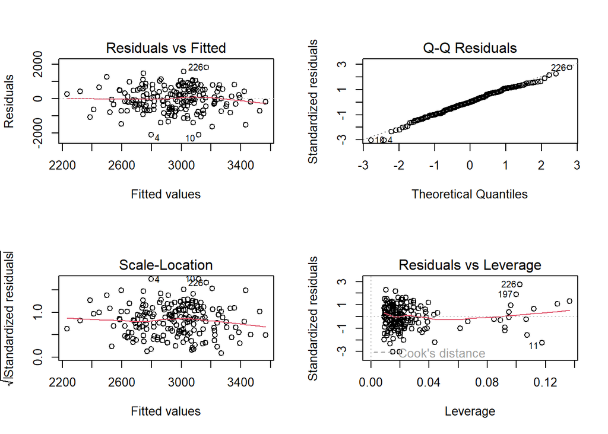

```r
par(mfrow = c(2, 2))
plot(model_full)
```

However we can use the package `performance` to analyse our model in depth. We can use `check_model` to see if our residuals have zero mean across the whole range fitted values. Explain your result.

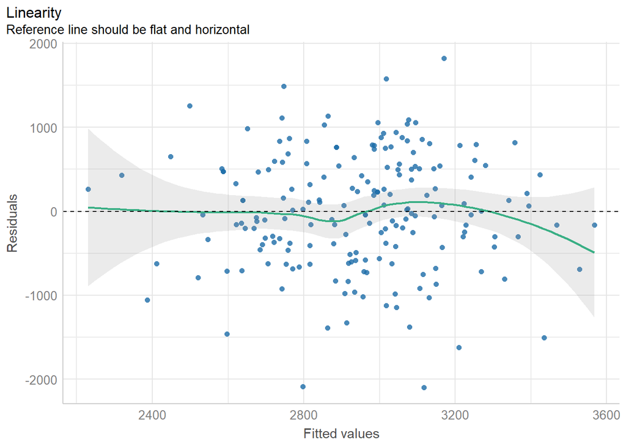

```r
check_model <- check_model(model_full, panel = FALSE, check = "linearity")
plot(check_model)
```

#### Exercise 14

Use `check_normality` to see if our residuals are normally distributed. Note that this formal test almost always yields strong evidence for the distribution of residuals and visual inspection (e.g. Q-Q plots) are preferable.

```r
normality_result <- check_normality(model_full)
normality_result
```

```
OK: residuals appear as normally distributed (p = 0.427).
```

Try to plot the QQ-plot of your normality_result with `plot()`. Do the dots follow the line? What does this mean?

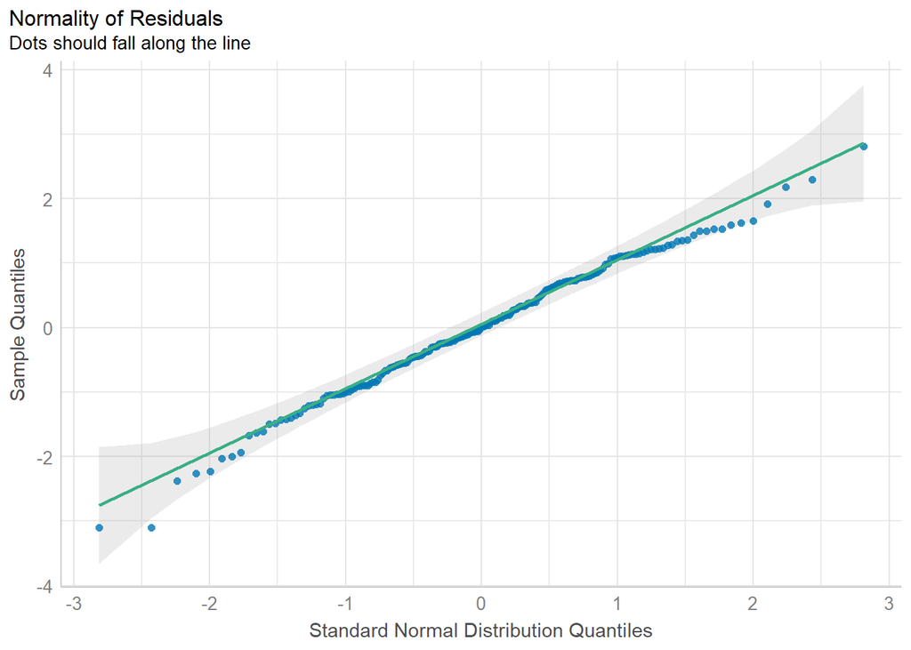

```r
plot(normality_result, type = "qq")
```

## Heteroscedasticity

#### Exercise 15

Use `check_heteroscedasticity` to test significance for linear regression models. We assume that the model errors (or residuals) have constant variance. If this assumption is violated the p-values from the model are no longer reliable.

```r
heteroscedasticity_result <- check_heteroscedasticity(model_full)
heteroscedasticity_result
```

```
OK: Error variance appears to be homoscedastic (p = 0.621).
```

Plot and interpret the `heteroscedasticity_result` with `plot()`.

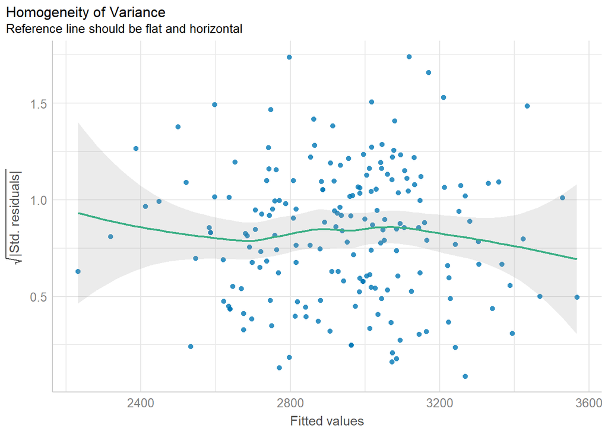

```r
plot(heteroscedasticity_result)
```

## Influence

#### Exercise 16

Checks for and locates influential observations (i.e., “outliers”) via several distance and/or clustering methods (default is Cook’s distance.

```r
outliers_result <- check_outliers(model_full, threshold = list('cook' = 1))
outliers_result
```

```
OK: No outliers detected.
- Based on the following method and threshold: cook (1).
- For variable: (Whole model)
```

Plot and interpret the `outliers_result` with `plot()`.

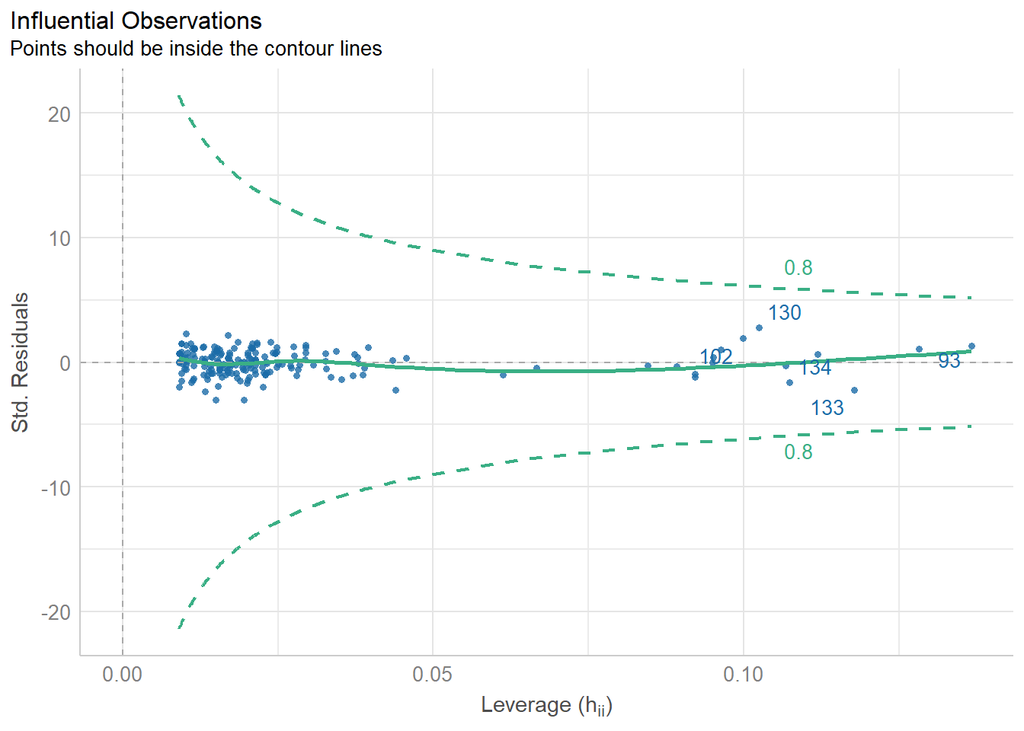

```r
plot(outliers_result)
```

## Multicollinearity (variance inflation factor)

#### Exercise 17

Use `vif()` to see if there are any problematic variables. Comment on the result.

```r
vif(model_full)
```

```
mother_smokes    mother_age mother_weight  hypertension
     1.003834      1.038703      1.100359      1.063673
```